# Psychologia_poznawcza

Agata Żbikowska

14 maja 2018

# Trzecie kolokwium

### wiedza i poznanie → funkcje wykonawcze → działanie

*Funkcje wykonawcze* to system przetwarzania informacji, występują między umysłem a działaniem. To takie programowanie wiedzy, kontrolowanie i modyfikowanie jej.

Zaburzenia funkcji wykonawczych u studenta:

- pisanie eseju bez materiałów
- problem z zaczęciem zadania
- problem z planowaniem zadania
- problem z samodzielnymi zadaniami
- wrażenie osoby rozproszonej/impulsywnej
- problem z zadaniami nagłymi/nowymi

Funkcje wykonawcze łączą się z mechanizmami uwagi. U organizmów wyższych zachodzi „sprzężenie zwrotne” ze świata wewnętrznego (prezka). Kiedy działamy to reagujemy. Jest to związane z aktywnością kory czołowej.

Tak zwany **cykl POSTERIOR-ANTERIOR** odnosi się do zjawisk mających miejsce w różnych miejscach w czasie ( post – przeszłość, ant – przyszłość ) Może zachodzić równolegle na kilku piętrach mózgu. Może dawać podstawę do f uwagi. Zapewnia nam do działania ponadczasowego (zadań wieloetapowych).

Struktury zaśrodkowe mózgu związane z przetwarzaniem działają „w tył”, buforują czas w tył. Kora skroniowa, potyliczna.

Struktury przedśrodkowe buforują czas „w przód”.Neurony kory przedczołowej mają zdolność do podtrzymywania pobudzenia(przetwarzania) podczas równoległego działania struktur zaśrodkowych.

Na nasze decyzje wpływa wiele czynników z przeszłości (emocje, prawne konsekwencje, wyuczone zachowania, język, ograniczenia etyczne … )

### Funkcje wykonawcze:

- zapewniają zdolność do inicjowania działań
- umożliwiają również hamowanie oraz powstrzymanie rozpoczętych działań
- są potrzebne w sytuacjach NOWYCH (kiedy obieramy nowe cele, plany)
- uruchamiają się w zadaniach trudnych, a nie w wykonywanych automatycznie
- są ukierunkowane na przyszłość, przewidywanie zadań i na przyszłe cele
- wiążą sytuacje „przyczynowo skutkowo”
- koordynują działania rozproszone w czasie
- umożliwiają wybór celu
- mają charakter metapoznawczy (umiejętność wyodrębnienia z siebie jakiegoś elementu, „stanięcia obok” i analizy sytuacji )
- zarządzają, regulują i sterują innymi procesami psychicznymi(emocjonalnymi, behawioralnymi)

### Funkcje wykonawcze a inne funkcje poznawcze

UWAGA (selektywność i odporność na dystrakcję) PAMIĘĆ OPERACYJNA

Inne połączone:

- funkcje abstrakcyjne (matematyczne działania, wyobrażenia, zakładanie jakiś scenariuszy odnośnie sytuacji)
- planowanie działania
- pamięć prospektywna - Dotyczy zapamiętywania planów i zamiarów – jest to pamiętanie o wykonaniu określonej czynności w przyszłości. Pamięć prospektywna, w odróżnieniu od pamięci retrospektywnej (dotyczącej zapamiętywania zdarzeń i faktów z przeszłości), dotyczy przyszłości. Koncentruje się na pamięci zadań, które mają być wykonane w określonym czasie i miejscu w przyszłości. Podczas gdy funkcją pamięci retrospektywnej jest przywoływanie informacji z przeszłości, w pamięci prospektywnej informacja może być wielokrotnie przywoływana. Zadanie będzie spełnione jedynie wtedy, gdy informacja zostanie wydobyta z pamięci w momencie, w którym zaplanowana czynność powinna być wykonana
- poznawcza estymacja
- płynność poznawcza, podtrzymanie i zmiana nastawienia (mental set)
- kontrola wykonawcza – test Stroopa (ten test z kolorami i napisami kolorów)

### Funkcje wykonawcze a procesy emocjonalno-motywacyjne

- dostarczają motywacji
- wspomagają procesy socjalizacji i możliwe dzięki temu interakcje społeczne
- pozwalają na samokrytycyzm
- umożliwiają samokontrolę
- pozwalają na odroczenie jakiegoś działania w wyższym celu później

To jak nasze funkcje wykonawcze działają zależy min.

adekwatność vs nieadekwatność reakcji do wymogów sytuacyjnych

poczucie dystansu vs zaburzenia poczucia dystansu społecznego ( brak jakiś regulacji w swoim zachowaniu społecznym np. wchodzenie w nadmierną bliskość z kimś )

empatia vs obniżona empatia

wgląd w siebie vs obniżony wgląd w siebie (ekstrawertyzacja)

uwzględnienie vs nieuwzględnienie konsekwencji (społecznych) własnego działania

Funkcje wykonawcze są bardzo trudne do zdefiniowania. Istnieje wiele definicji z których każda zawiera w sobie ziarnko prawdy. Zazwyczaj definiuje się fw jako funkcje wyższego rzędu.

### Modele funkcji wykonawczych

- **Model Broadbenta** – teoria szyjki od butelki model przetwarzania informacji, odnosi się do FW przez wyjaśnienie funkcji uwagi

  ```
    przetwarzanie automatyczne → przetwarzanie kontrolowane
  działanie poza świadomością            świadoma uwaga
  ```

- **Model Treisman** - teoria filtru uwagi
- **Model Posnera i Snydera** - Posner zakładał, że istnieją automatyczne systemy aktywacji.
- **Model Shiffrina & Schneidera** - Różnice w przetwarzanie automatycznym vs przetwarzaniu kontrolowanym. (do kolokwium)

| automatyczne | kontrolowane |
| --- | --- |
| * szybkie | * wolne |
| * nie zużywają zasobów poznawczych | * zużywają zasoby poznawcze |
| * mogą zachodzić po kilka na raz | * wymagają procesów wyższych (synteza, analiza) |

## MODEL NADZORUJĄCEGO SYSTEMU UWAGI-ważne (TO NOTOWAŁA KLAUDUSIA)

Koncepcja, realizacja-Jeśli robimy coś świadomie to my o tym wiemy, podpisujemy się pod tym

Podczas wykonywania zadań poznawczych czasami są potrzebne świadome zasoby, a czasami nie

Potrzeba świadomości:

- jeśli zadanie wymaga planowania i podejmowania decyzji
- jeśli to co robimy jest składową jakiegoś problemu
- kiedy jakaś czynność jest jeszcze niedostatecznie wyuczona
- kiedy zadania są niebezpiecznie lub trudne technicznie
- kiedy musimy się przeciwstawić bardzo silnej wyuczonej tendencji

Automatyczne działania możemy poddać świadomości i kontroli, powstrzymać nawykowe rekcje jeśli jest do tego powód. Np. test Stroopa

Mamy schematy działania. To czy my wybierzemy jakiś schemat działania zależy od: zjawiska w środowisku bodźcowym, procesy poznawcze wyższych rzędów.

Rywalizacja programów działania- miedzy wyuczonymi działaniami przebiega rywalizacja, wybrany zostanie jeden z dostępnych działania na podstawie : zjawisk w środowisku bodźcowym, procesy poznawcze wyższych rzędów.

Dla zadań nawykowych istnieją i działają na nie pewne wyzwalacze działania. Kiedy nie ma wcześniej działających schematów działania np. w nowych zadaniach włącza nam się nadzorujący system uwagi(manipuluje recznie prawdopodobieństwem aktywacji którychś ze schematów działania)

#### Nadzorujący system uwagi = centralny system uwagi

Dlaczego działa wątek pionowy i poziomy?

**Poziomy**- jest szybki, nie potrzeba wiele zasobów, ale plastyczność tego systemu jest ograniczona do bardzo dobrze znanych sytuacji

**Pionowy**- nie ma ograniczeń jeśli chodzi o zawartość zużytych zasobów, ale potrzeba do nich wszystkich naszych zasobów poznawczych, tracimy automatyzmy

Ten model nie obejmuje tego że działania nowe, powtórzone kilka razy staje się automatycznie, niezależne od nadzorującego systemu uwagi. Najprawdopodobniej wyuczamy się tych schematów.

**Uczenie probabilistyczne**- efektem działania jest podjęcie określonej decyzji, próbujemy podjąć decyzje w oparciu o wiele bodźców, podjęcie decyzji A lub nie A(tej lub przeciwnej), nieświadome, mamy mnóstwo wiedzy tak wyuczonej, a nawet o tym nie wiemy

- **MODEL ANDERSONA**

Funkcje wykonawcze próbujemy zrozumieć w 4 formach:

- Giętkość poznawcza- uwaga, inf zwrotne, pamięć operacyjna, podzielność uwagi
- Określenie celu działania- inicjowanie działania, planowanie, organizacja
- Przetwarzanie informacji- sprawność, płynność
- Kontrolująca funkcja uwagi- uwaga selektywna, samokontrola, wygaszanie Każdy z każdym reaguje.

**MYŚLENIE I ROZWIĄZYWANIE PROBLEMÓW**

1. Myślenie wymaga wystąpienia w umyśle(pamięci operacyjnej) :

   • Reprezentacji realnych lub abstrakcyjnych obiektów • Operacji przetwarzania informacji zawartych w tych reprezentacjach

Te operacje zachodzą według stosownych do problemu reguł. Rola myślenia:

```
• Testowanie sytuacji potencjalnie rzeczywistych(pozwala na wybór optymalnej procedury zachowania spośród kilku możliwych, przydatne zwłaszcza w sytuacjach nowych)
• Testowanie rozwiązań odnoszących się do sytuacji z definicji abstrakcyjnych(przydatne w rozwoju nauk formalnych np. logika, matematyka, przydatne  w rozwoju umiejętności myślenia, przygotowywanie rozwiązań dla sytuacji które mogą zdarzyć się w przyszłości)
```

2. Default Mode Network

3.Jakie są typy myślenia?

Myślenie produktywne- nie oznacza twórcze Myślenie reproduktywne

4. Rozwój myślenia( teoria Piageta):
- Stadium rozwoju sensoryczno- motorycznego( do 2 r.ż.) Dzieci zauważają przyczynowo skutkowość, powtarzanie wzorców, zmienianie wzorców, wytwarzanie schematów wielozmysłowych, dostrzega zmienność i permanentność obiektów,zdolność do reprezentowania przedmiotów- dzięki temu możliwe jest natychmiastowe poprawne ustawienie obiektu w oparciu o wykonaną wcześniej w wyobraźni rotacje, intencjonalność działania
- Stadium myślenia przedoperacyjnego (od 2 do 7) Dzieci posługują się wzrokowymi reprezentacjami wyobrażonych obiektów w procesach myślenia, pojawia się zabawa symboliczna, rysunek, mowa, uczą się powstrzymywać wrodzony egocentryzm , pojawia się odroczone naśladownictwo, porządkowanie obiektów z uwagi na nasilenie danej cechy, klasyfikacja, utrzymywanie w umyśle dwóch relacji naraz, odwracalność( wałeczek z plasteliny uformowany z identycznej kulki )
- Stadium operacji konkretnych( od 7 do 11) Rozwój operacji logicznych w pełnej odwracalności, pełne reprezentacje umysłowe, w sytuacjach sprzeczności danych percepcyjnych i rozumowania zwycięża rozumowanie, wszystko to umie zrobić tylko jeśli przeżył to w praktyce
- Stadium operacji formalnych(od11) Możliwe jest działanie na reprezentacjach abstrakcyjnych, problemy rozwiązywane dotyczą KLAS sytuacji a nie pojedynczej sytuacji, mogą być natychmiast generalizowane na sytuacje nowe, możliwe operacje wnioskowania indukcyjnego i dedukcyjnego

#### Teorie myślenia:

- **Teoria Dawida Berlyne** – nawiązuje do tradycji behawiorystycznej, myślenie jest ciągiem związków bodziec-reakcja, przy czym charakter jest symboliczny a nie realny
- **Teoria Jonathana Barona** - operacje myślowe: poszukiwanie(możliwości, dowody, cele) i wnioskowanie

#### Klasyfikacje operacji umysłowych

```
• Analiza – synteza
• Algorytmy – heurystyki
```

Heurystyka: zacznij od tyłu- wyobrażanie sobie efektu, sytuacji końcowej Byle bliżej

Transformacje np. transformacja zerowa- nie zmienia stanu obiektu

#### Rozumowanie sylogistyczne

Wariant rozumowania dedukcyjnego w którym istnieją dwie przesłanki (mniejsza i większa) np: Drzewa są większe od krzaków -> krzaki są większe od trawy -> drzewa są większe od trawy

Często występują błędy rozumowania sylogistycznego: zależą od kontekstu wiedzy i atmosfery (prezka)

#### Rozumowanie warunkowe

Orzeka o kierunku związku przyczynowego

Zagadka Petera Catharta Wasona (1966) :

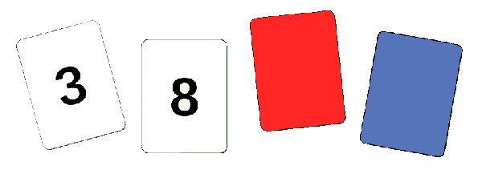

fot.6

### Myślenie i rozwiązywanie problemów

##### Problemy są dywergencyjne i konwergencyjne.

Dywergencyjne : drogi prowadzące do postawienia problemu do rozwiązania prowadzą do różnych stanów docelowych z punktu widzenia treści rozwiązania niemniej każda zawiera w sobie rozwiązania. Jak nie podejdziemy do problemu będziemy mieli kilka różnych rozwiązań.

Konwergencyjne : jak nie podejdziemy do sytuacji istnieje **JEDNO** rozwiązanie.

Sytuacje dobrze określone to takie, w których występuje jeden cel, albo też wiele celów. Gdy mamy do czynienia z jednym celem, pojawia sie myślenie konwergencyjne, czyli myslenie zbieżne. Do tego celu można dochodzić różnymi drogami albo tylko jedną drogą. Często autorzy rozmaitych testów tak formułują problemy, że mają one tylko jedno poprawne rozwiązanie. Gdy myslenie ukierunkowane jest na wiele celów, to w fazie wstepnej nastepuje ich selekcja- wybierane są takie, których osiągnięcie pozwala na maksymalizowanie rozmaitych korzyści albo unikanie niebezpieczeństw. Jest to myślenie dywergencyjne, które często pojawia sie u ofiar przemocy, np. maltretowana kobieta może zastanawiać się na tym jak przerwać swoja tragiczna sytuację- może myslec o rozwodzie, o samodzielnym wymierzeniu sprawiedliwości, o opuszczeniu męża,albo czekać aż mąż sam sie opamieta.

“Psychologia poznania” Maruszewski

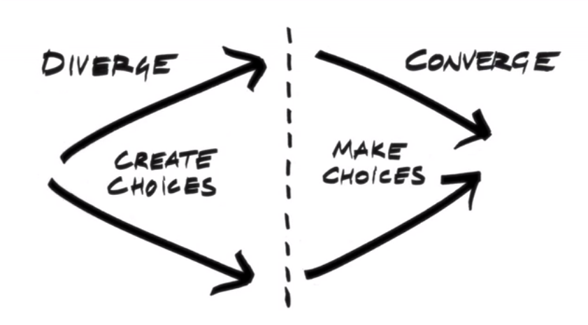

fot.7.

##### Problemy proste i złożone

Problemy *proste* zazwyczaj mają jeden wątek i są rozwiązywane przez wgląd. Problemy *złozone* są wielowątkowe.

#### Fazy rozwiązywania problemów:

1. Identyfikowanie problemu-problemy są nam zadawane, zauważane przez nas lub wykorzystywane
2. Definiowanie problemu
3. Dobranie strategii rozwiązania (zbiór informacji i przydzielanie zasobów)
4. Monitorowanie postępów
5. Ocena poprawności

Przeszkody w efektywnym myśleniu :

*sztywność myślenia (sztywność związana z nawykiem, trudność w zmianie myślenia o przestrzeni problemowej, trudność w wytworzeniu różnych rozwiązań zwłaszcza pod presją czasu)* nastawienie

### Wydawanie sądów i podajmowanie decyzji

Decyzja-wybór możliwości działania

Wydawanie sądów - wydawanie wprost stwierdzenia na jakiś temat, prowadzące do jakiejś decyzji

- mogą mieć charakter intuicyjny
- sądy antyintuicyjne - odnoszą się do cech, nas samych i innych ludzi
- sądy probabilistyczne
- sądy wartościujące

**Paradoks hazardzisty** to przeświadczenie o zalezności zdarzeń niezależnych.

Złudzenie koniunkcji najczesciej dotyczy cech.

##### Heurystyka dostępności

- wydarzenia bliższe czasowo są pamiętane lepiej
- złudzenie osobistego doświadczenia
- stosowanie heurystykki zakotwiczenia i dopasowania
- efekt potwierdzenia

**Sądy intuicyjne** to sądy potoczne oraz alogiczne. Jest to kumulacja nieświadomego doświadczenia.

zysk x prawdopodobieństwo jego uzyskania -> decyzja

**Herbert A. Simon 1956, Strategia “wystarczajączej satysfakcji”**

Decydenci poszukują wystarczającego rozwiązania a nie najlepszego.

**Amos Tversky 1972, Strategia eliminacji wg. aspektów**

przykład : reklama z eliminacją (prezka)

**Gigerenzer, Todd 1999**

Heurystyki powinny być najprostsze (kieruj się tym co dla Ciebie najważniejsze). Ludzie kierują się tym aby były *szybkie*-podejmowane w krótkim czasie oraz *oszczędne*-najmniej angażujące funkcje poznawcze

Ludzie wpierw analizują która CECHA jest dla nich najważniejsza, potem porównują parami. Jeżeli nie da się wybrać z pary to kierujemy się cechą następną po naważniejszej i znowu porównujemy dwójkami. Jeżeli to nie pomaga to wybieramy opcję która ostatnio się udała(usłyszeliśmy o takim przypadku albo sami go przeżyliśmy), dopiero na końcu wybieramy “na odwal”

**Efekt obramowania (Tversky & Kahnemann 1981)**

## Procesy poznawcze, a procesy emocjonalne

Emocje są stanami subiektywnymi, są również trudne do formalnego badania.

Emocje towarzyszące procesom poznawczych mogą wpłynąć na ich przebieg (osądy, podejmowanie ryzyka, myślenie, zapamiętywanie).

Emocje mogą wpływać na stan organizmu (reakcje fizyczne min hormony, stan skóry, napięcie mięśni, częstość oddechu).

Wiążą się z rozwojem układu nerwowego (układ limbiczny).

**Procesy interpretacji danych sytuacyjnych** Jak procesy poznawcze wpływają na wywołanie emocji?

- **Jaki jest wpływ emocji na przebieg procesów poznawczych?**

#### Podejście kategorialne

Paul Ekhman, Carroll E. Izard Istnieje kilka stałych, jakościowo odmiennych uniwersalnych emocji np. gniew, wstręt, strach, szczęście, smutek, zdziwienie

#### Wundt i jego ujęcie wymiarowe

Wilhelm Wundt założył, że emocje rozkładają się na wymiarach. W oparciu o bardziej podstawowe stany emocjonalne rozkładając emocje na ich wymiarach możemy określić bardziej szczegółowe stany emocjonalne.

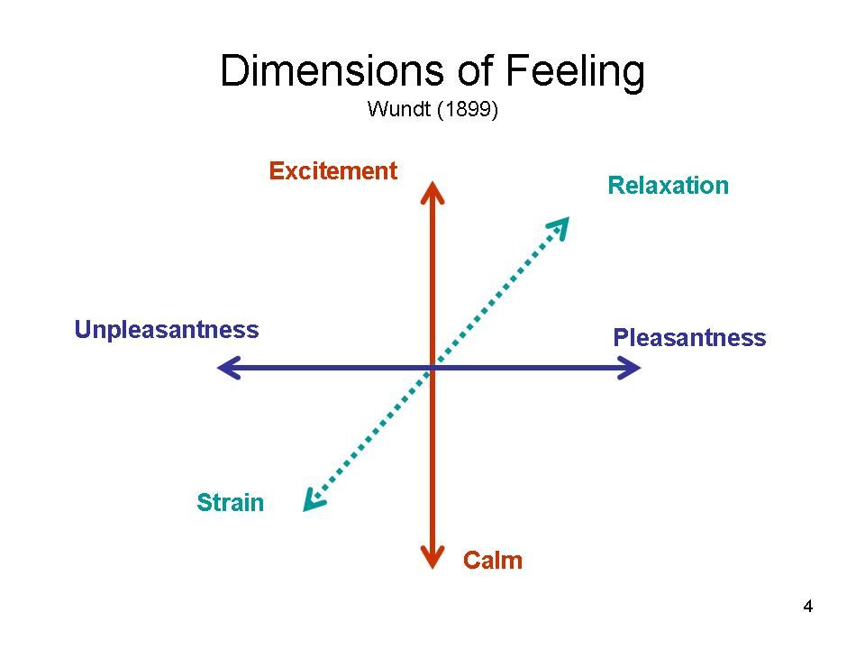

fot.11

#### Russell

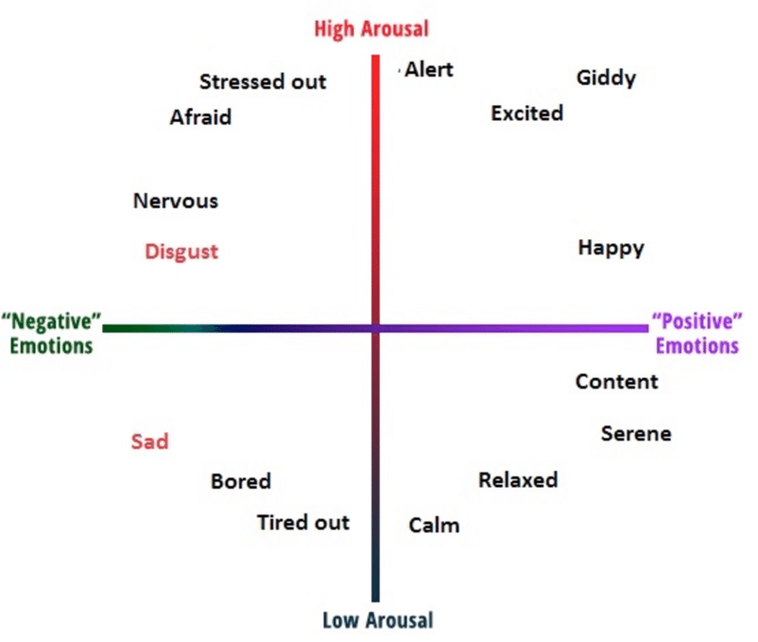

fot.12

To co jest trefne w jego teorii to to, że wg niego emocje po dwóch przeciwnych stanach wymiarów nie mogą występować razem (a np ludzie mogą jednocześnie płakać i się śmiać)

#### Watson i Tellegen

Negują teorię Russella.

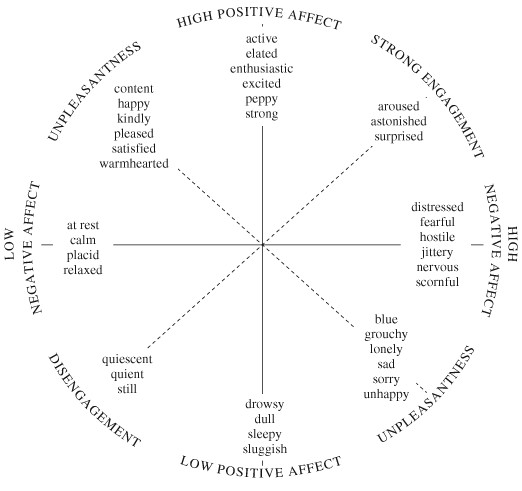

fot.13

### Negativity bias - asymetria pozytywno-negatywna

Większe znaczenie mają oceny negatywne niż oceny pozytywne. Np Jeden zadowolony klient powie średnio 5 osobom o udanym zakupie, a jeden niezadowolony powie 10-12 osobom.

### Teoria Cannona-Barda

- Emocje i pobudzenie pojawiają się w tym samym czasie

### Teoria Jamesa-Langego

- Emocja jest wynikiem pobudzenia
- Pierwsza teoria tego typu
- Wg nich odczuwamy strach ponieważ drżymy
- Ma zastosowanie do emocji które oczuwamy fizycznie
- Dzięki temu hipoteza “markera somatycznego” Damasio

### Dwuczynnikowa teoria emocji Schachtera i Singera

Pobbudzenie i poznanie łączą się tworząc emocje. Eksperyment ze strzykawkami(?)

#### Warianty tego co pojawia się pierwsze w warunkach analizy złożonych sytuacji bodźcowych

1. Klasyczne ujęcie : procesy poznawcze dominują i decydują o wyborze emocji. Wg klasycznej teorii Lazarusa (1966,1982) istnieją trzy formy interpretacji:
- Interpretacja podstawowa - sytuacje interpretuje się jako pozytywną ALBO stresująca ALBO nieistotna dla nas (wpierw sytuacje interpretujemy w stosunku do siebie)
- Interpretacja wtórna - bierze się pod uwagę zasoby, którymi dysponuje osoba aby poradzić sobie z daną sytuacją
- Reinterpretacja wtórna - sytuacja bodźcowa i strategia radzenia sobie z sytuacją są ponownie analizowane, a interpretacja wtórna i podstawowa mogą zostać zmodyfikowane

W 1993 Smirh i Lazarus rozbudowali tę teorię i wyodrębnili sześć elementów interpretacji (prezka).

2. Sądy emocjonalne mogą powstawać *przed* sądami poznawczymi lub *bez wsparcia* procesów poznawczych (Zajonc) Nie trzeba się dowiadywać aby wiedzieć co się woli.

#### Efekt ekspozycji - Robert Zajonc

#### Joseph E. LeDoux i jego dwie ścieżki procesów emocjonalnych

1. Droga krótka: bodziec -> wzgórze -> ciało migdałowate -> reakcja emocjonalna
2. Droga długa: bodziec -> kora nowa/sensoryczna -> hipokamp -> ciało migdałowate -> reakcja emocjonalna

Istnieją dwie ścieżki gdyż pozwala nam to być elastycznym w ocenie sytuacji:

- Droga krótka - np sytuacja ucieczki
- Droga długa - np sytuacja analizy jakiegoś problemu

### Rola emocji dla procesów poznawczych

- Funkcja informacyjna
- Funkcja aktywacyjna - emocje są paliwem dot. przeprowadzenia różnych procesów poznawczych
- Funkcja modulacyjna - emocje mogą podtrzymać proces poznawczy